# StatR 502 Lab 1

Sunday, January 11, 2016

```r
knitr::opts_chunk$set(cache = TRUE, fig.width = 6, fig.height = 2.75)
```

Remember key points from last week:

- ggplots are *objects*
- `aes()` is where we set *aesthetic mappings* from data to aesthetic plotting concepts.
- Use *unquoted* column names inside `aes()`, **never** `data$column`.

And a couple key points for this week:

- Work on getting your *data* right, and plotting should be easy.

## Jumping in where we left off

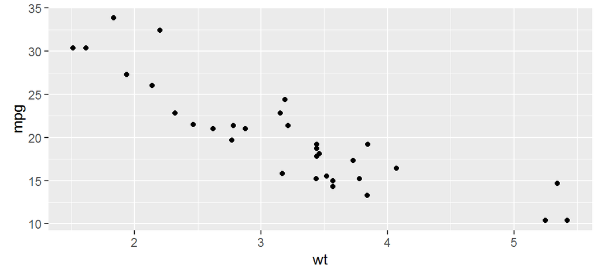

```r
library(ggplot2)
# new dataset name (for convenience)
mt = mtcars
mtplot = ggplot(mt, aes(x = wt, y = mpg)) +
    geom_point()
print(mtplot)
```

## Adding color

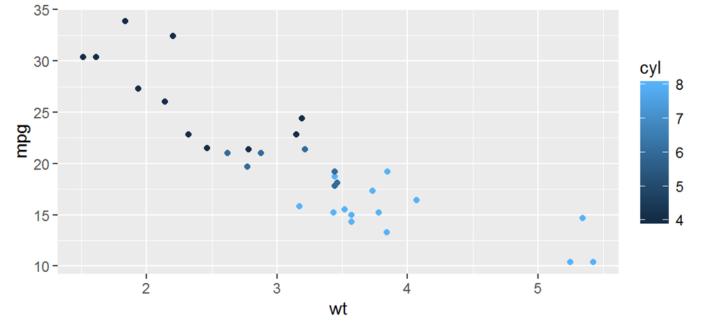

```r
ggplot(mt, aes(x = wt, y = mpg, color = cyl)) +
    geom_point()
```

## Discrete vs. continuous

```r
# but `cyl` is discrete!
table(mt$cyl)
```

```
##
##  4  6  8
## 11  7 14
```

```r
# why do we have this continuous color scale?
```

## Discrete vs. continuous

```r
# but `cyl` is discrete!
table(mt$cyl)
```

```
##
##  4  6  8
## 11  7 14
```

```r
# why do we have this continuous color scale?
class(mt$cyl)
```

```
## [1] "numeric"
```

Column `class` is very important to `ggplot`.

Continuous (numeric) vs. discrete (factor, character) is what you'll use most of the time. You can either modify your data or do it on-the-fly. I generally prefer to modify the data (`mt$cyl = as.factor(mt$cyl)`), but here's doing it on-the-fly:

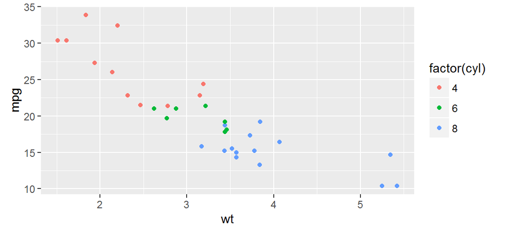

```r
mtplot + geom_point(aes(color = factor(cyl)))
```

Notice that (a) I can modify the existing plot, even overwriting existing aesthetic mappings, and (b) I can also set `aes()` inside a `geom` layer.

But now let's modify that data because I don't want to type `factor(cyl)` for the rest of the lab:

```r
mt$cyl = as.factor(mt$cyl)
# and redefine the plot with the new data
mtplot = ggplot(mt, aes(x = wt, y = mpg, color = cyl)) +
    geom_point()
```

Do be careful converting factors to numerics!!!

```r
head( mt$cyl                           , 10)
```

```
##  [1] 6 6 4 6 8 6 8 4 4 6
## Levels: 4 6 8
```

```r
head( as.numeric(mt$cyl)               , 10)
```

```
##  [1] 2 2 1 2 3 2 3 1 1 2
```

```r
head( as.numeric(as.character(mt$cyl)) , 10)
```

```
##  [1] 6 6 4 6 8 6 8 4 4 6
```

## Labeling is easy

Aesthetics are labeled by name in `labs()`.

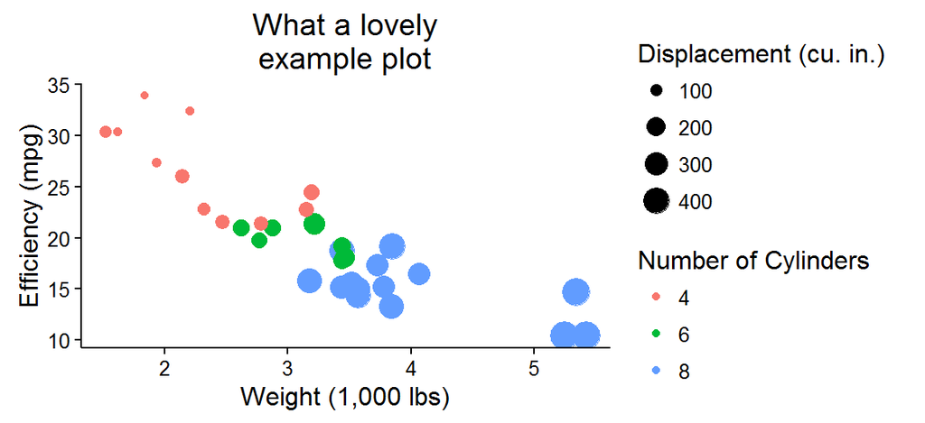

```r
mtplot +
  geom_point(aes(color = cyl, size = disp)) +
  theme_classic() +
  labs(x = "Weight (1,000 lbs)",
       y = "Efficiency (mpg)",
       color = "Number of Cylinders",
       size = "Displacement (cu. in.)",
       title = "What a lovely\nexample plot")
```

## Consistent syntax

- everything is lower case (**general Hadleyverse**)
- function names use underscore for word separation (`geom_point`) (**general Hadleyverse**)
- if there's a data argument, it will be first (**general Hadleyverse**)
- for data that is plotted directly, the plotting function is a `geom`
- other statistical summaries are `stat`s
- labels are in the `labs` function
- `scale` functions determine, e.g., axis limits, transformations.

## Default themes

The default is `theme_grey`. Many others are available (see `?ggtheme` for a few… or the whole [`ggthemes` package](https://cran.r-project.org/web/packages/ggthemes/vignettes/ggthemes.html)).

You can change your default theme for the rest of your R session with `theme_set()`

```r
theme_set(theme_bw())
```

## Let's get plotting

## Small multiples

Small multiples, or *facets*, are trivial with ggplot.

## More facets

- `facet_wrap` vs. `facet_grid`

## Common and less common aesthetics

- `x`, `y`
- `color` and `fill`
- `size`, `linetype`, `shape`
- `alpha`, is for transparency
- geom-specific aesthetics

## Adding new geoms

And how to read geom help files

## Scales

- Cynthia Brewer's color palettes at http://colorbrewer2.org/. These are available in the `RColorBrewer` package, is imported by ggplot.
- Breaks and values
- Transformations

## Theming

- Some `ggthemes` themes
- Why are themes functions?

There's a whole vignette on creating and customizing themes: http://docs.ggplot2.org/dev/vignettes/themes.html. We'll cover theme modifications in the future…

## Putting several plots together

- `gridExtra::grid.arrange()` is like `par(mfrow)`/`mfcol`

## Scales vs coordinate systems

- zooming with `coord_cartesian(xlim, ylim)` vs clipping with `scale` functions
- other coordinate systems

## Common "gotchas" in ggplot2

- ggplot is built on the `grid` graphics system. This is completely separate system from base graphics, and there is **no overlap** in plotting functions.
- ggplot is made to work with data in *long* form (not *wide* form).
- line breaks between geoms/layers/scales - don't forget to end a line with `+` if your plot continues
- don't use `data$column` inside `aes()`
- anything you set to a **constant** - doesn't vary with your data - is set **outside** `aes()`
- data types ("discrete value supplied to continuous scale")
- fill vs. color